# R Notebook

```r
library(mlbench)
library(caret)
library(AppliedPredictiveModeling)
library(nnet)
library(earth)
library(kernlab)
library(MASS)
library(forecast)
library(tidyverse)
library(Metrics)
library(Amelia)
library(doParallel)
library(missForest)
library(cwhmisc)
library(pls)
```

Chapter 7 Homework HW 7.2 and 7.5

7.2 Friedman (1991) introduced several benchmark data sets created by simulation. One of these simulations used the following nonlinear equation to create data:

$$y = 10sin(\pi x_1 x_2) + 20(x_3 -0.5)^2+10x_4 +5x_5 + N(0,\sigma^2)$$
where the ex values are random variables uniformly distributed between [0,1] (there are also 5 0other non-informative variables also created in simulation). The package mlbench contains a function called mlbench.friedman1 that simulates these data:

```r
set.seed(1234)
trainingData <- mlbench.friedman1(200, sd = 1)
trainingData$x <- data.frame(trainingData$x)
#featurePlot(trainingData$x, trainingData$y)
testData <- mlbench.friedman1(5000, sd = 1)
testData$x <- data.frame(testData$x)
```

Tune several models on these data.

> Training Neural Net

```r
nnetFit <- nnet(testData$x, testData$y,
                size = 5,
                decay = .01,
                maxit = 500,
                MaxNWts = 5 * (ncol(testData$x) + 1) + 5 + 1)
results <- predict(nnetFit, trainingData$x) %>% cbind(.,trainingData$y) %>% as.data.frame()
colnames(results) <- c("predicted", "actual")
rmse(results$actual, results$predicted)
```

```
[1] 14.36606
```

> Training MARS

```r
marsFit <- earth(testData$x, testData$y)
results <- predict(marsFit, trainingData$x) %>% cbind(.,trainingData$y) %>% as.data.frame()
colnames(results) <- c("predicted", "actual")
rmse(results$actual, results$predicted)
```

```
[1] 1.785523
```

> Train K-Nearest Neighbors

> This method at times will work and other times will not due to a known issue with the latest caret release. The error is “unable to find variable”optimismBoot“”, I am leaving the code in to show my attempt but note that this will not run appropriately.

```r
#At one point I got the error optimismBoot not found
knnTune <- train(testData$x, testData$y,
                method = "knn",
                preProc = c("center", "scale"))
results <- predict(knnTune, trainingData$x) %>% cbind(.,trainingData$y) %>% as.data.frame()
colnames(results) <- c("predicted", "actual")
rmse(results$actual, results$predicted)
```

Which models appear to give the best performance? Does MARS select informative predictors (those named X1-X5).

> The model with the lowest performance metric that we are using is the RMSE value of 1.7855 for the MARS method.

```r
varImp(marsFit)
```

|  | Overall |
| --- | --- |
| X4 | 100.00000 |
| X1 | 78.68733 |
| X2 | 63.36434 |
| X5 | 44.56206 |
| X3 | 31.99334 |
| X6 | 0.00000 |
| X7 | 0.00000 |
| X8 | 0.00000 |
| X9 | 0.00000 |
| X10 | 0.00000 |

> The MARS method did select variables with the most important of X1-X5 as shown in our previous table.

7.5 Exercise 6.3 describes data for a chemical manufacturing process. Use the same data imputation, data splitting, and pre-processing steps as before and train several nonlinear regression models.

> The below is the minimum steps needed to recreate the data set from Chapter 6. Please see problem from Chapter 6 for complete breakdown for each step and reasons behind the choices.

```r
library(AppliedPredictiveModeling)
data("ChemicalManufacturingProcess")
```

```r
library(missForest)
set.seed(1234)
registerDoParallel(cores=3)
chem.imput <- missForest(ChemicalManufacturingProcess, ntree = 100)$ximp
```

```
  missForest iteration 1 in progress...done!
  missForest iteration 2 in progress...done!
  missForest iteration 3 in progress...done!
  missForest iteration 4 in progress...done!
```

```r
data.set <- list(org.data.set = chem.imput)
```

```r
trans.data.set <- data.set$org.data.set %>%
                    mutate(BiologicalMaterial04.boxcoxtrans =
                             BoxCox(BiologicalMaterial04, -0.99992424816297),
                           ManufacturingProcess01.boxcoxtrans =
                             BoxCox(ManufacturingProcess01, 1.99995900720725),
                           ManufacturingProcess02.boxcoxtrans =
                             BoxCox(ManufacturingProcess02, 1.99995900720725),
                           ManufacturingProcess03.boxcoxtrans =
                             BoxCox(ManufacturingProcess03, -0.99992424816297),
                           ManufacturingProcess06.boxcoxtrans =
                             BoxCox(ManufacturingProcess06, -0.99992424816297),
                           ManufacturingProcess07.boxcoxtrans =
                             BoxCox(ManufacturingProcess07,-0.99992424816297),
                           ManufacturingProcess08.boxcoxtrans =
                             BoxCox(ManufacturingProcess08, 1.99992424816297),
                           ManufacturingProcess12.boxcoxtrans =
                             BoxCox(ManufacturingProcess12, 0.0000410225926326142),
                           ManufacturingProcess16.boxcoxtrans =
                             BoxCox(ManufacturingProcess16, 1.99995900720725),
                           ManufacturingProcess18.boxcoxtrans =
                             BoxCox(ManufacturingProcess18, 1.99995900720725))
```

```r
data.set <- c(data.set, list(trans.data.set = trans.data.set))  %>%
            c(., list(train.test.split = floor(0.75 * nrow(chem.imput)))) %>%
            c(., train.index = list(sample(seq_len(nrow(chem.imput)), size = .$train.test.split))) %>%
            c(., train = list(as.data.frame(trans.data.set[.$train.index,])), test = list(as.data.frame(trans.data.set[-.$train.index,])))
```

## Model Selection

> Training Neural Net

```r
nnetFit <- nnet(data.set$train %>% dplyr::select(-Yield), data.set$train$Yield,
                size = 5,
                decay = .01,
                maxit = 500)
results <- predict(nnetFit,data.set$test %>% dplyr::select(-Yield)) %>% cbind(.,data.set$test$Yield) %>% as.data.frame()
colnames(results) <- c("predicted", "actual")
rmse(results$actual, results$predicted)
```

```
[1] 38.89715
```

> Training MARS

```r
marsFit <- earth(data.set$train %>% dplyr::select(-Yield), data.set$train$Yield)
results <- predict(marsFit, data.set$test %>% dplyr::select(-Yield)) %>% cbind(.,data.set$test$Yield) %>% as.data.frame()
colnames(results) <- c("predicted", "actual")
rmse(results$actual, results$predicted)
```

```
[1] 1.401761
```

> Attempts to model a K-nearest neighbor was unsuccesful, the caret package appears to have a conflict with optimismboot and is unable to accomodate this data set. https://stackoverflow.com/questions/46244763/caret-train-function-unable-to-find-variable-optimismboot
1. Which nonlinear regression model gives the optimal re-sampling and test set performance?

> The nonlinear regression model with the best test set performance was again the MARS model with an RMSE of 1.401761.
2. Which predictors are the most important in the optimal nonlinear regression model? Do either the biological or process variables dominate the list? How do the top ten important predictors compare to the top ten predictors from the optimal linear model?

```r
library(data.table)
dt <- setDT(varImp(marsFit), keep.rownames = TRUE)[]
options(scipen=99)
dt[order(-Overall)]
```

| rn | Overall |
| --- | --- |
| ManufacturingProcess32 | 100.00000 |
| ManufacturingProcess09 | 67.72174 |
| ManufacturingProcess13 | 42.33973 |
| ManufacturingProcess33 | 37.43641 |
| BiologicalMaterial02 | 37.25570 |
| BiologicalMaterial03 | 37.25570 |
| ManufacturingProcess28 | 31.32309 |
| ManufacturingProcess43 | 27.29428 |
| ManufacturingProcess04 | 19.81703 |
| BiologicalMaterial05 | 12.51240 |

[output cut: 57 more lines]

> We see that the Manufacturing Processes dominate the list for variable importance with a few biological materials having importance. This is similar to our previous model however we do see a few more biological materials variables. Although we see none of the variables are previous model found important which suggests that the manufacturing processes contain a lot of information on the variance of yield.
3. Explore the relationships between the top predictors and the response for the predictors that are unique to the optimal nonlinear regression model. Do these plots reveal intuition about the biological or process predictors and their relationship with yield?

```r
subset.data.set <- data.set$trans.data.set %>%
                      dplyr::select(ManufacturingProcess32, ManufacturingProcess09,
                             ManufacturingProcess13,    ManufacturingProcess33,
                             BiologicalMaterial02,  BiologicalMaterial03,
                             ManufacturingProcess28, ManufacturingProcess43,
                             ManufacturingProcess04, BiologicalMaterial05, Yield)
```

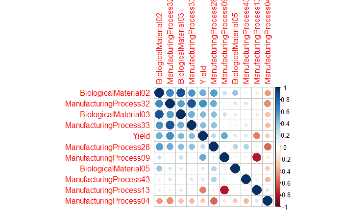

```r
library(corrplot)
correlations <- cor(subset.data.set)
corrplot(correlations, order = "FPC", diag = TRUE)
```

> The correlation plot provides some insight to these important variables. Yield has a mostly positive correlation with many of hte processes but has the strongest negative correlation with only manufacturing processes from our top 10 variables. We also see some very high correlations with other variables in our top variable set which suggests possible issues of multicollinearity.